# Analysis of Dative Priming Data at 42 months

Seamus Donnelly

2022-01-24

# 1 Opening Files

```r
library(brms)
library(readxl)
library(writexl)
library(rmarkdown)
library(tidybayes)
library(ggplot2)
library(tidyr)
library(dplyr)
library(GGally)
library(ggpubr)
library(tidybayes)
library(patchwork)
library(sjPlot)
library(lubridate)
library(zoo)
```

```r
DOD_42mo <- read_xlsx("DOD_42mo_blind.xlsx")
N_total <- nrow(DOD_42mo) # sanity check
```

Create mismatch variables. I’m also creating some character versions of many factors to make plotting a bit easier later.

```r
DOD_42mo <- DOD_42mo %>%
 mutate(
    Prime = ifelse(Prime.Type==.5, yes="DOD", no="POD"), # Prime type, character version
    Overlap = ifelse(Verb.match==.5, yes="Overlap", no="No Overlap") # overlap
    )

DOD_42mo$bias <-"DOD" # set as DOD bias
DOD_42mo$bias[DOD_42mo$Prime.verb=="passed"] = "POD" # Change POD-biased prime verbs.
DOD_42mo$bias[DOD_42mo$Prime.verb=="sent"] = "POD"
DOD_42mo$bias[DOD_42mo$Prime.verb=="threw"] = "POD"

DOD_42mo$biasmatch <-"match" # set to match

DOD_42mo$biasmatch[DOD_42mo$bias=="POD" & DOD_42mo$Prime == "DOD"] = "mismatch" # Change to mismatch.
DOD_42mo$biasmatch[DOD_42mo$bias=="DOD" & DOD_42mo$Prime == "POD"] = "mismatch"

table(DOD_42mo$biasmatch)
```

```
##
##    match mismatch
##      541      539
```

```r
DOD_42mo$biasmismatchc <- ifelse(DOD_42mo$biasmatch == "mismatch", yes=.5, no=-.5)
```

# 2 Missing data

There is one type of trial coded as an admin error that I don’t want to remove at the time being – trials 12r on lists 6 and 8.

```r
DOD_42mo <- DOD_42mo %>%
  mutate(
    Trial_Drop = ifelse(is.na(RESPONSE.CODE), yes=1, no=0),
    Trial_Problem = ifelse(List==6 & Item == "12r", yes = 1, no =ifelse(
      List==8 & Item == "12r", yes = 1, no =0
    ) )
  )

nrow(filter(DOD_42mo, Trial_Problem==1)) == (nrow(filter(DOD_42mo, List==6))/12) + (nrow(filter(DOD_42mo, List==8))/12)
```

```
## [1] TRUE
```

```r
N_miss <- DOD_42mo %>%
  filter(is.na(RESPONSE.CODE)) %>%
  nrow()

N_Prob = nrow(filter(DOD_42mo, Trial_Problem==1))
```

```r
DOD_42mo %>%
  summarise(
    Verb_Error = sum(Verb.error, na.rm=TRUE),
    Admin_Error = sum(Admin.error, na.rm=TRUE),
    Prompts.disallowed = sum(Prompts.disallowed, na.rm=TRUE),
    Prep_Error = sum(Prep.error.bin, na.rm=TRUE),
    Reversal_Error = sum(Reversal.error, na.rm=TRUE),
    NonTargetResponse = sum(NonTarget.response, na.rm=TRUE),
    No_Response = sum(No.response, na.rm=TRUE),
    GavePOD = sum(Gave.POD, na.rm=TRUE)
     )
```

```
## # A tibble: 1 × 8
##   Verb_Error Admin_Error Prompts.disallowed Prep_Error Reversal_Error
##        <dbl>       <dbl>              <dbl>      <dbl>          <dbl>
## 1         26          11                 57         72              3
## # … with 3 more variables: NonTargetResponse <dbl>, No_Response <dbl>,
## #   GavePOD <dbl>
```

216 non-target responses (this includes lots of stuff, non-dative responses, preposition errors, etc).

That means 24 are other types of errors.

```r
DOD_42mo %>%
 filter(is.na(NonTarget.response) & is.na(RESPONSE.CODE)) %>%
  summarise(
    Verb_Error = sum(Verb.error, na.rm=TRUE),
    Admin_Error = sum(Admin.error, na.rm=TRUE),
    Prompts.disallowed = sum(Prompts.disallowed, na.rm=TRUE),
    Prep_Error = sum(Prep.error.bin, na.rm=TRUE),
    Reversal_Error = sum(Reversal.error, na.rm=TRUE),
    NonTargetResponse = sum(NonTarget.response, na.rm=TRUE),
    No_Response = sum(No.response, na.rm=TRUE),
    GavePOD = sum(Gave.POD, na.rm=TRUE)
     )
```

```
## # A tibble: 1 × 8
##   Verb_Error Admin_Error Prompts.disallowed Prep_Error Reversal_Error
##        <dbl>       <dbl>              <dbl>      <dbl>          <dbl>
## 1         16           8                  1          0              0
## # … with 3 more variables: NonTargetResponse <dbl>, No_Response <dbl>,
## #   GavePOD <dbl>
```

See how many missing values we have by participant, and make indicator variables for (a) participants missing more than 10 trials and (b) participants missing more than 6 trials.

```r
DOD_42mo %>%
  group_by(Blind_ID) %>%
  mutate(
    N_Missing = sum(is.na(RESPONSE.CODE))
  ) %>%
  slice(1) %>%
  select("Blind_ID", "N_Missing") %>%
  group_by(N_Missing) %>%
  count()
```

```
## # A tibble: 12 × 2
## # Groups:   N_Missing [12]
##    N_Missing     n
##        <int> <int>
##  1         0    25
##  2         1    19
##  3         2    15
##  4         3    10
##  5         4     3
##  6         5     1
##  7         6     6
##  8         8     4
##  9         9     1
## 10        10     2
## 11        11     1
## 12        12     3
```

```r
DOD_42mo <- DOD_42mo %>%
  group_by(Blind_ID) %>%
  mutate(
    N_Missing = sum(is.na(RESPONSE.CODE))
  ) %>%
  slice(1) %>%
  select("Blind_ID", "N_Missing") %>%
  mutate(
    Drop = ifelse(N_Missing >= 10, 1, 0), # Participants missing 10
    MightDrop = ifelse(N_Missing > 6, 1, 0)
  )  %>%
  full_join(DOD_42mo, .)
N_drop = DOD_42mo %>%
  filter(Drop == 1 & !is.na(RESPONSE.CODE)) %>% # save number of additional missing trials.
  count()
```

And by item.

```r
DOD_42mo %>%
  group_by(Target.verb) %>%
  mutate(
    N_Missing = sum(is.na(RESPONSE.CODE))
  ) %>%
  slice(1) %>%
  select("Target.verb", "N_Missing") %>%
  group_by(Target.verb)
```

```
## # A tibble: 11 × 2
## # Groups:   Target.verb [11]
##    Target.verb N_Missing
##    <chr>           <int>
##  1 brought            41
##  2 gave               38
##  3 passed             33
##  4 push                2
##  5 pushed              1
##  6 putting             1
##  7 rolled              1
##  8 sent               31
##  9 showed             46
## 10 threw              45
## 11 vroomed             1
```

All non-target verbs (**putting**, **rolled** etc) have been removed. It doesn’t make sense to estimate random effects for a level of a random factor with only a single observation.

And let’s just check the proportion of missing trials across the various experimental conditions.

```r
DOD_42mo %>%
  mutate(
    Missing = ifelse(is.na(RESPONSE.CODE), yes=1, no = 0)
  ) %>%
  group_by(Prime, Overlap) %>%
  summarise(
    mean = mean(Missing),
    sd = sd(Missing)
  )
```

```
## # A tibble: 4 × 4
## # Groups:   Prime [2]
##   Prime Overlap     mean    sd
##   <chr> <chr>      <dbl> <dbl>
## 1 DOD   No Overlap 0.254 0.436
## 2 DOD   Overlap    0.219 0.414
## 3 POD   No Overlap 0.253 0.435
## 4 POD   Overlap    0.168 0.374
```

```r
DOD_42mo %>%
  mutate(
    Missing = ifelse(is.na(RESPONSE.CODE), yes=1, no = 0)
  ) %>%
  group_by(Prime, biasmatch) %>%
  summarise(
    mean = mean(Missing),
    sd = sd(Missing)
  )
```

```
## # A tibble: 4 × 4
## # Groups:   Prime [2]
##   Prime biasmatch  mean    sd
##   <chr> <chr>     <dbl> <dbl>
## 1 DOD   match     0.252 0.435
## 2 DOD   mismatch  0.219 0.415
## 3 POD   match     0.199 0.400
## 4 POD   mismatch  0.219 0.414
```

```r
DOD_42mo <- filter(DOD_42mo, !is.na(RESPONSE.CODE) & Drop==0) # 835

nrow(DOD_42mo) == N_total - N_miss - N_drop
```

```
##         n
## [1,] TRUE
```

Descriptive Statistics

```r
DOD_42mo %>%
  summarise(
    min = min(Session.Age),
    max = max(Session.Age)
  )
```

```
## # A tibble: 1 × 2
##   min     max
##   <chr>   <chr>
## 1 41 : 27 43 : 5
```

# 3 Plot Data

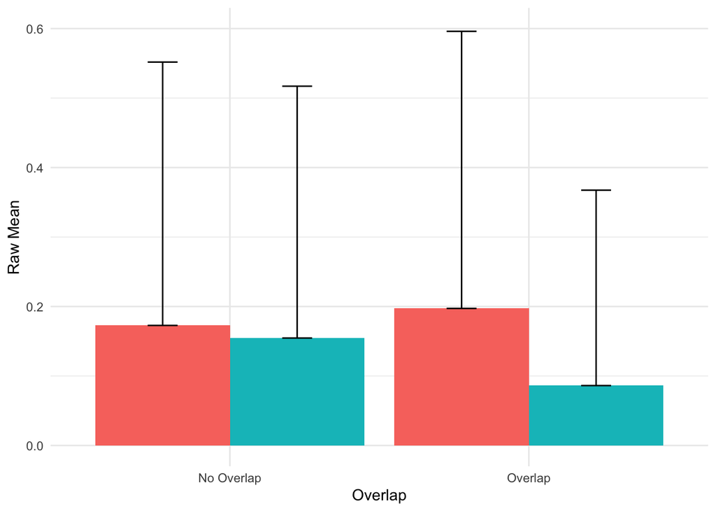

```r
(p1 <- DOD_42mo %>%
  group_by(Prime, Overlap) %>%
  summarise(mean = mean(RESPONSE.CODE, na.rm=TRUE),
            sd = sd(RESPONSE.CODE, na.rm=TRUE)) %>%

ggplot(aes(y=mean, x=Overlap, fill=Prime)) +
  geom_bar(stat="identity",position="dodge") +
 geom_errorbar(aes(ymin=mean, ymax=mean+sd), width=.2,
                 position=position_dodge(.9)) +
  ylim(0, .6) +
  theme_minimal() +
  labs(y="Raw Mean") +
  theme(legend.position = "none")
)
```

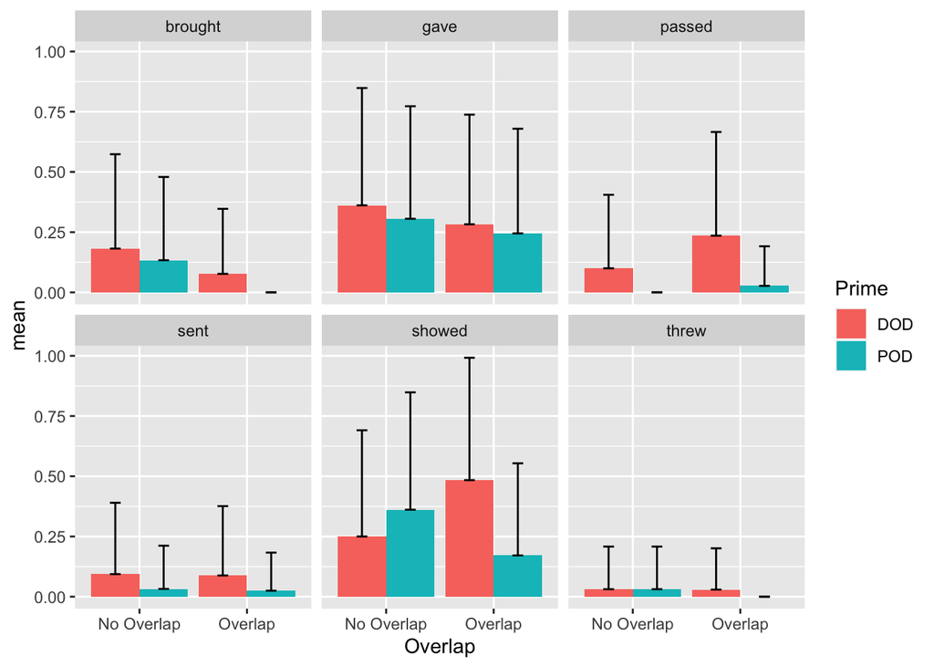

```r
DOD_42mo %>%
  group_by(Prime, Overlap, Target.verb) %>%
  summarise(mean = mean(RESPONSE.CODE, na.rm=TRUE),
            sd = sd(RESPONSE.CODE, na.rm=TRUE)) %>%

ggplot(aes(y=mean, x=Overlap, fill=Prime)) +
  geom_bar(stat="identity",position="dodge") +
 geom_errorbar(aes(ymin=mean, ymax=mean+sd), width=.2,
                 position=position_dodge(.9)) +
  facet_wrap(~Target.verb)
```

And let’s look at the pattern of responses when we only consider participants who produced at least 1 DOD.

```r
DOD_42mo <- DOD_42mo %>%
  group_by(Blind_ID) %>%
  mutate(
    Prod_DOD = sum(RESPONSE.CODE)
  ) %>%
  dplyr::select(Blind_ID, Prod_DOD) %>%
  slice(1) %>%
  ungroup() %>%
  full_join(DOD_42mo, ., by="Blind_ID")

writexl::write_xlsx(DOD_42mo, "DOD_42mo_prepped.xlsx")
```

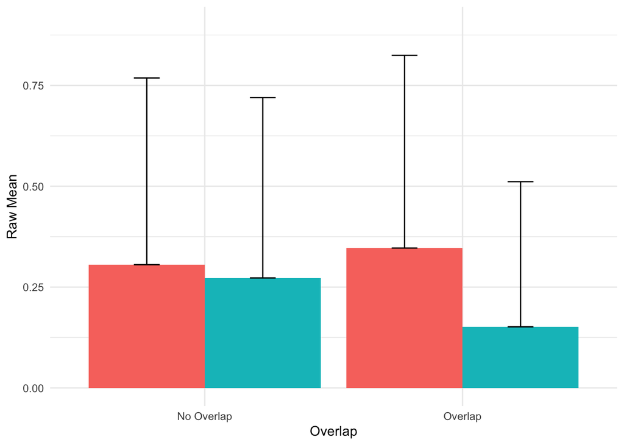

```r
DOD_42mo2 <- filter(DOD_42mo, Prod_DOD > 0)

(p1b <- DOD_42mo2 %>%
  group_by(Prime, Overlap) %>%
  summarise(mean = mean(RESPONSE.CODE, na.rm=TRUE),
            sd = sd(RESPONSE.CODE, na.rm=TRUE)) %>%

ggplot(aes(y=mean, x=Overlap, fill=Prime)) +
  geom_bar(stat="identity",position="dodge") +
 geom_errorbar(aes(ymin=mean, ymax=mean+sd), width=.2,
                 position=position_dodge(.9)) +
  ylim(0, .9) +
  theme_minimal() +
  labs(y="Raw Mean") +
  theme(legend.position = "none")
)
```

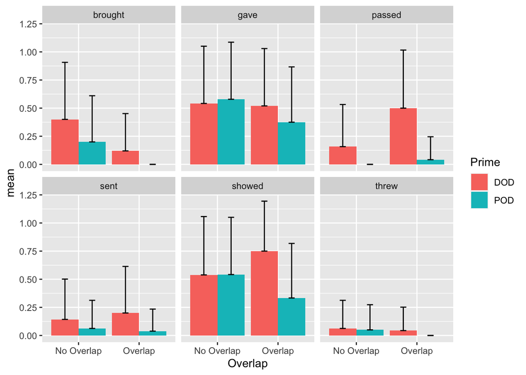

```r
DOD_42mo2 %>%
  group_by(Prime, Overlap, Target.verb) %>%
  summarise(mean = mean(RESPONSE.CODE, na.rm=TRUE),
            sd = sd(RESPONSE.CODE, na.rm=TRUE)) %>%

ggplot(aes(y=mean, x=Overlap, fill=Prime)) +
  geom_bar(stat="identity",position="dodge") +
 geom_errorbar(aes(ymin=mean, ymax=mean+sd), width=.2,
                 position=position_dodge(.9)) +
  facet_wrap(~Target.verb)
```

Maybe a bit different for **brought** but we’re working with less data here and the overlap condition appears to be at floor.

Plot proportion of DOD responses by each cell in two-way interaction between biasmatch and prime type.

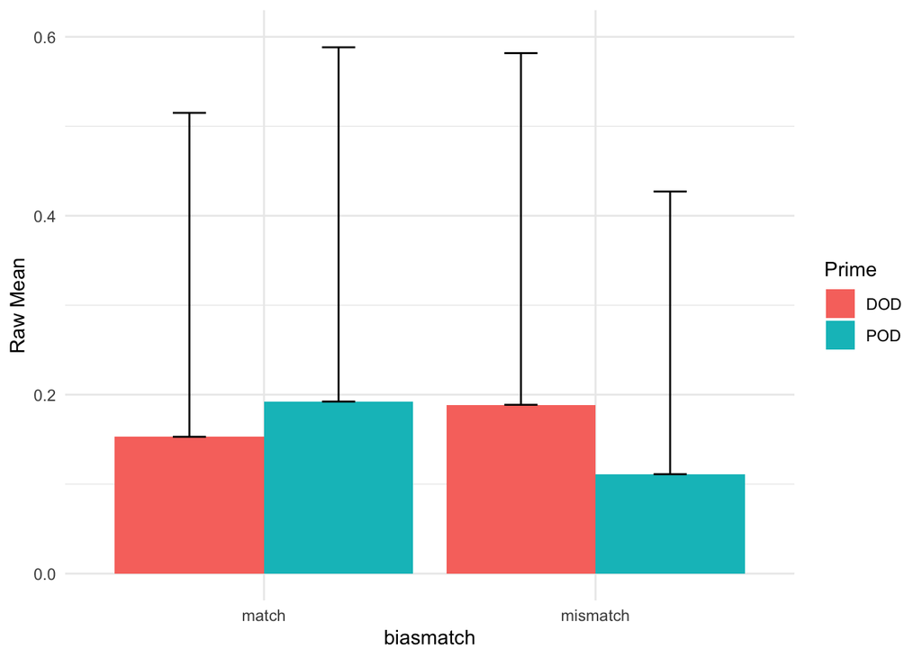

```r
(p1c <- DOD_42mo %>%
  filter(Overlap == "No Overlap") %>%
  group_by(Prime, biasmatch) %>%
  summarise(mean = mean(RESPONSE.CODE, na.rm=TRUE),
            sd = sd(RESPONSE.CODE, na.rm=TRUE)) %>%

ggplot(aes(y=mean, x=biasmatch, fill=Prime)) +
  geom_bar(stat="identity",position="dodge") +
 geom_errorbar(aes(ymin=mean, ymax=mean+sd), width=.2,
                 position=position_dodge(.9)) +
  ylim(0, .6) +
  theme_minimal() +
  labs(y="Raw Mean")
)
```

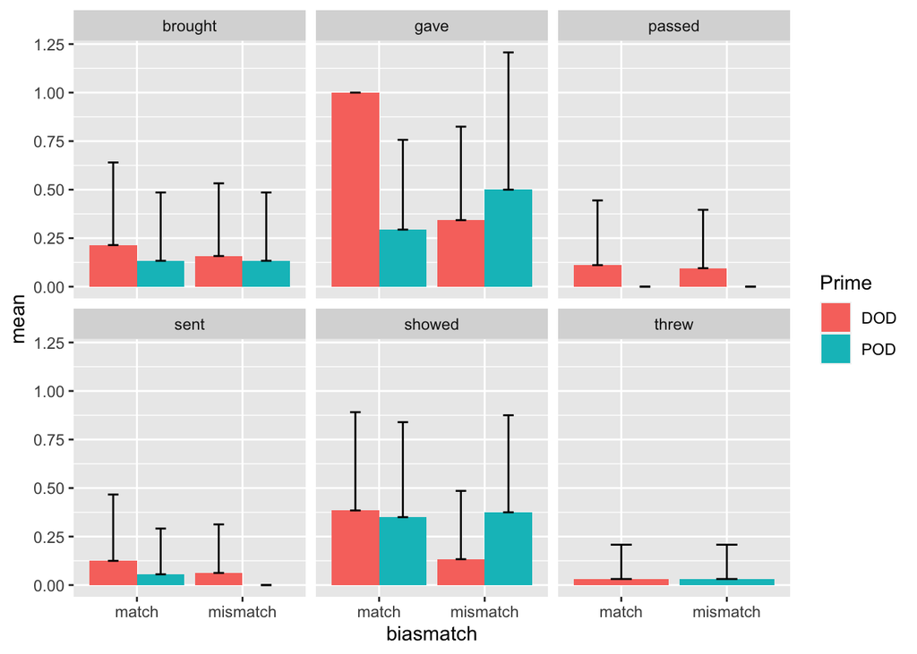

```r
DOD_42mo %>%
  filter(Overlap == "No Overlap") %>%
  group_by(Prime, biasmatch, Target.verb) %>%
  summarise(mean = mean(RESPONSE.CODE, na.rm=TRUE),
            sd = sd(RESPONSE.CODE, na.rm=TRUE)) %>%

ggplot(aes(y=mean, x=biasmatch, fill=Prime)) +
  geom_bar(stat="identity",position="dodge") +
 geom_errorbar(aes(ymin=mean, ymax=mean+sd), width=.2,
                 position=position_dodge(.9)) +
  facet_wrap(~Target.verb)
```

Notice that **threw** only had DODs in prime bias match and PODs in prime bias mismatch. This is because the two verbs that primed **threw** were both DOD-biased verbs. The opposite should be true for **gave**; however, on some trials participants produced **gave** instead of the target verb provided by the experimenter. We can see the numbers of those below:

```r
DOD_42mo %>%
  filter(Overlap == "No Overlap") %>%
  group_by(Target.verb, Prime, biasmatch) %>%
  count()
```

```
## # A tibble: 22 × 4
## # Groups:   Target.verb, Prime, biasmatch [22]
##    Target.verb Prime biasmatch     n
##    <chr>       <chr> <chr>     <int>
##  1 brought     DOD   match        14
##  2 brought     DOD   mismatch     19
##  3 brought     POD   match        15
##  4 brought     POD   mismatch     15
##  5 gave        DOD   match         1
##  6 gave        DOD   mismatch     35
##  7 gave        POD   match        34
##  8 gave        POD   mismatch      2
##  9 passed      DOD   match         9
## 10 passed      DOD   mismatch     21
## # … with 12 more rows
```

And we can see more information about these 3 specific trials.

```r
DOD_42mo %>%
   filter(Overlap == "No Overlap") %>%
   filter(Target.verb=="gave" & Prime=="DOD" & biasmatch == "match")
```

```
## # A tibble: 1 × 48
##   Blind_ID Gender D.O.B.              Session.Date        Session.Age
##   <chr>     <dbl> <dttm>              <dttm>              <chr>
## 1 aOusW0Av      1 2014-08-10 00:00:00 2018-03-02 00:00:00 42 : 20
## # … with 43 more variables: Sess.Age.(Days) <dbl>, List <dbl>, Item <chr>,
## #   Prime.verb <chr>, Target.verb <chr>, Prime.Type <dbl>, Verb.match <dbl>,
## #   Verb.error <dbl>, Verb.error_systematic <dbl>, Admin.error <dbl>,
## #   Repeat.prime <dbl>, Repeat.target.prompt <dbl>, Prime.interference <dbl>,
## #   Missing.article <dbl>, Pronoun <chr>, Prep.error <chr>,
## #   Prep.error.bin <dbl>, Reversal.error <dbl>, Prompts.allowable <dbl>,
## #   Prompts.disallowed <dbl>, NonTarget.response <dbl>, No.response <dbl>, …
```

```r
DOD_42mo %>%
   filter(Overlap == "No Overlap") %>%
   filter(Target.verb=="gave" & Prime=="POD" & biasmatch == "mismatch")
```

```
## # A tibble: 2 × 48
##   Blind_ID Gender D.O.B.              Session.Date        Session.Age
##   <chr>     <dbl> <dttm>              <dttm>              <chr>
## 1 AUD17Yu2      0 2014-10-26 00:00:00 2018-05-17 00:00:00 42 : 21
## 2 LkVZQCTn      1 2015-09-23 00:00:00 2019-04-15 00:00:00 42 : 23
## # … with 43 more variables: Sess.Age.(Days) <dbl>, List <dbl>, Item <chr>,
## #   Prime.verb <chr>, Target.verb <chr>, Prime.Type <dbl>, Verb.match <dbl>,
## #   Verb.error <dbl>, Verb.error_systematic <dbl>, Admin.error <dbl>,
## #   Repeat.prime <dbl>, Repeat.target.prompt <dbl>, Prime.interference <dbl>,
## #   Missing.article <dbl>, Pronoun <chr>, Prep.error <chr>,
## #   Prep.error.bin <dbl>, Reversal.error <dbl>, Prompts.allowable <dbl>,
## #   Prompts.disallowed <dbl>, NonTarget.response <dbl>, No.response <dbl>, …
```

# 4 Lexical Boost

## 4.1 All Participants

BRMS’s default priors on random effects are a bit wide (the 95% CI on the prior extends out to 10). Given that these are going to be difficult to estimate in the current design (very few words), I’ve decided to use slightly more informative priors. These will pull random effects away from really implausible values. These still aren’t especially informative – the 95% CI on the prior should extend out to a bit past 4, which is still a large value for a random effect **sd**.

```r
logit_prior = prior(normal(0,2), class=sd)
```

First lets consider whether we should include random effects by the interaction between ID and Item. In principle this is possible, but I think it will greatly complicate the model. So I’ll fit two variance component models with the two random effects specifications and compare them to one another.

```r
m0<- brm(RESPONSE.CODE ~ 1 + (1 | Blind_ID) + (1 | Target.verb),  family="bernoulli", prior=logit_prior, iter=4000, cores=4, data=DOD_42mo, file="42mo/output/m0.rds")
```

```r
m0b <- brm(RESPONSE.CODE ~ 1 + (1 | Blind_ID) + (1 | Target.verb) + (1 | Blind_ID:Target.verb),  family="bernoulli", prior=logit_prior, iter=4000, cores=4, data=DOD_42mo, file="42mo/output/m0b.rds")
```

Add loo for loo_compare

```r
m0<- add_criterion(m0, "loo")
m0b<- add_criterion(m0b, "loo")
```

```r
loo(m0, m0b, reloo=TRUE)
```

```
## Output of model 'm0':
##
## Computed from 8000 by 835 log-likelihood matrix
##
##          Estimate   SE
## elpd_loo   -257.0 16.8
## p_loo        50.2  4.2
## looic       514.1 33.5
## ------
## Monte Carlo SE of elpd_loo is 0.1.
##
## Pareto k diagnostic values:
##                          Count Pct.    Min. n_eff
## (-Inf, 0.5]   (good)     831   99.5%   1521
##  (0.5, 0.7]   (ok)         4    0.5%   1655
##    (0.7, 1]   (bad)        0    0.0%   <NA>
##    (1, Inf)   (very bad)   0    0.0%   <NA>
##
## All Pareto k estimates are ok (k < 0.7).
## See help('pareto-k-diagnostic') for details.
##
## Output of model 'm0b':
##
## Computed from 8000 by 835 log-likelihood matrix
##
##          Estimate   SE
## elpd_loo   -258.0 16.8
## p_loo        63.0  5.2
## looic       515.9 33.6
## ------
## Monte Carlo SE of elpd_loo is NA.
##
## Pareto k diagnostic values:
##                          Count Pct.    Min. n_eff
## (-Inf, 0.5]   (good)     821   98.3%   849
##  (0.5, 0.7]   (ok)        11    1.3%   644
##    (0.7, 1]   (bad)        3    0.4%   667
##    (1, Inf)   (very bad)   0    0.0%   <NA>
## See help('pareto-k-diagnostic') for details.
##
## Model comparisons:
##     elpd_diff se_diff
## m0   0.0       0.0
## m0b -0.9       0.8
```

```r
model_weights(m0, m0b)
```

```
##           m0          m0b
## 9.999970e-01 3.043396e-06
```

Simpler model fits numerically better.

Here’s the model of the lexical boost.

```r
m1 <- brm(RESPONSE.CODE ~ 1 + Prime.Type*Overlap  +  (1 +  Prime.Type*Overlap | Blind_ID) + (1 +  Prime.Type*Overlap   | Target.verb), logit_prior,family="bernoulli", cores=4, data=DOD_42mo, file="42mo/output/m1.rds")

m1<- add_criterion(m1, "loo")
```

```r
summary(m1)
```

```
##  Family: bernoulli
##   Links: mu = logit
## Formula: RESPONSE.CODE ~ 1 + Prime.Type * Overlap + (1 + Prime.Type * Overlap | Blind_ID) + (1 + Prime.Type * Overlap | Target.verb)
##    Data: DOD_42mo (Number of observations: 835)
##   Draws: 4 chains, each with iter = 2000; warmup = 1000; thin = 1;
##          total post-warmup draws = 4000
##
## Group-Level Effects:
## ~Blind_ID (Number of levels: 84)
##                                               Estimate Est.Error l-95% CI
## sd(Intercept)                                     1.97      0.36     1.34
## sd(Prime.Type)                                    1.03      0.58     0.05
## sd(OverlapOverlap)                                0.68      0.48     0.03
## sd(Prime.Type:OverlapOverlap)                     1.23      0.79     0.06
## cor(Intercept,Prime.Type)                         0.15      0.39    -0.66
## cor(Intercept,OverlapOverlap)                     0.32      0.41    -0.58
## cor(Prime.Type,OverlapOverlap)                   -0.01      0.43    -0.80
## cor(Intercept,Prime.Type:OverlapOverlap)          0.30      0.39    -0.58
## cor(Prime.Type,Prime.Type:OverlapOverlap)         0.09      0.42    -0.73
## cor(OverlapOverlap,Prime.Type:OverlapOverlap)     0.08      0.44    -0.75
##                                               u-95% CI Rhat Bulk_ESS Tail_ESS
## sd(Intercept)                                     2.76 1.00     1716     2630
## sd(Prime.Type)                                    2.20 1.00      989     1403
## sd(OverlapOverlap)                                1.84 1.00     1215     2171
## sd(Prime.Type:OverlapOverlap)                     2.97 1.00     1338     1902
## cor(Intercept,Prime.Type)                         0.81 1.00     4051     2671
## cor(Intercept,OverlapOverlap)                     0.90 1.00     3684     2738
## cor(Prime.Type,OverlapOverlap)                    0.79 1.00     2941     2753
## cor(Intercept,Prime.Type:OverlapOverlap)          0.88 1.00     3783     2867
## cor(Prime.Type,Prime.Type:OverlapOverlap)         0.82 1.00     3098     2816
## cor(OverlapOverlap,Prime.Type:OverlapOverlap)     0.84 1.00     3055     3415
##
## ~Target.verb (Number of levels: 6)
##                                               Estimate Est.Error l-95% CI
## sd(Intercept)                                     1.91      0.66     0.95
## sd(Prime.Type)                                    0.68      0.53     0.03
## sd(OverlapOverlap)                                1.39      0.77     0.19
## sd(Prime.Type:OverlapOverlap)                     1.11      0.76     0.06
## cor(Intercept,Prime.Type)                        -0.23      0.43    -0.90
## cor(Intercept,OverlapOverlap)                     0.09      0.37    -0.62
```

[output cut: 16 more lines]

```
## Population-Level Effects:
##                           Estimate Est.Error l-95% CI u-95% CI Rhat Bulk_ESS
## Intercept                    -2.84      0.90    -4.58    -1.08 1.00     2073
## Prime.Type                    0.42      0.63    -0.75     1.72 1.00     3561
## OverlapOverlap               -0.97      0.83    -2.80     0.59 1.00     2453
## Prime.Type:OverlapOverlap     1.29      1.03    -0.69     3.41 1.00     3258
##                           Tail_ESS
## Intercept                     2794
## Prime.Type                    3268
## OverlapOverlap                2649
## Prime.Type:OverlapOverlap     2911
##
## Draws were sampled using sampling(NUTS). For each parameter, Bulk_ESS
## and Tail_ESS are effective sample size measures, and Rhat is the potential
## scale reduction factor on split chains (at convergence, Rhat = 1).
```

```r
hypothesis(m1, "Prime.Type > 0")
```

```
## Hypothesis Tests for class b:
##         Hypothesis Estimate Est.Error CI.Lower CI.Upper Evid.Ratio Post.Prob
## 1 (Prime.Type) > 0     0.42      0.63    -0.59      1.5       3.06      0.75
##   Star
## 1
## ---
## 'CI': 90%-CI for one-sided and 95%-CI for two-sided hypotheses.
## '*': For one-sided hypotheses, the posterior probability exceeds 95%;
## for two-sided hypotheses, the value tested against lies outside the 95%-CI.
## Posterior probabilities of point hypotheses assume equal prior probabilities.
```

```r
hypothesis(m1, "Prime.Type:OverlapOverlap > 0")
```

```
## Hypothesis Tests for class b:
##                 Hypothesis Estimate Est.Error CI.Lower CI.Upper Evid.Ratio
## 1 (Prime.Type:Overl... > 0     1.29      1.03    -0.34        3       9.96
##   Post.Prob Star
## 1      0.91
## ---
## 'CI': 90%-CI for one-sided and 95%-CI for two-sided hypotheses.
## '*': For one-sided hypotheses, the posterior probability exceeds 95%;
## for two-sided hypotheses, the value tested against lies outside the 95%-CI.
## Posterior probabilities of point hypotheses assume equal prior probabilities.
```

A quick check that the posterior predictive distribution looks okay.

```r
pp_check(m1)
```

```
## Using 10 posterior draws for ppc type 'dens_overlay' by default.
```

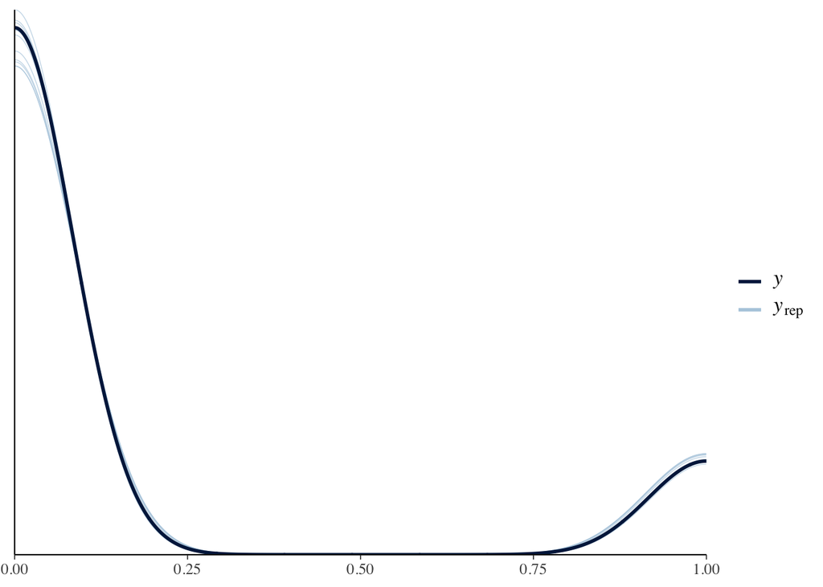

A quick check that the chains look okay.

```r
#plot(m1)
# commented out for space reasons
```

Nothing stands out.

Drop problem trials and re-fit. Drop participants with intermediate missing data and re-fit. Drop trials with high Pareto’s k and re-fit. None of these make a huge different, so I’ve excluded this output from this html file, but see R Markdown file for full details.

Plot model-predicted values + sd of posterior with raw data next to it for comparison.

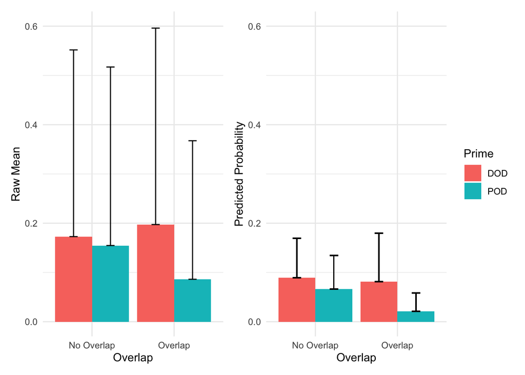

```r
p2 <- fitted(m1, re_formula=NA, scale="response") %>%
  cbind(DOD_42mo) %>%
  dplyr::select(Prime, Overlap, Estimate, Est.Error) %>%
  ggplot(aes(y=Estimate, x=Overlap, fill=Prime )) +
  geom_bar(stat="identity",position="dodge") +
  geom_errorbar(aes(ymin=Estimate, ymax=Estimate+Est.Error), width=.2,
                 position=position_dodge(.9)) +
  theme_minimal() +
  ylim(0, .6) +
  labs(y="Predicted Probability") +
  theme(legend.position = "none")


p1 | p2 + plot_layout(guides = "collect") & theme(legend.position = "right")
```

Plot risk ratios

```r
library("tidybayes")
ps_means1 <- posterior_samples(m1) %>%
  dplyr::select(Intc = "b_Intercept", Prime = "b_Prime.Type", Overlap= "b_OverlapOverlap", Int = "b_Prime.Type:OverlapOverlap") %>%
  mutate(
    DOD_no = inv_logit_scaled(Intc + .5*Prime),
    POD_no = inv_logit_scaled(Intc  - .5*Prime),
    RR_ap = DOD_no/POD_no,
    DOD_o = inv_logit_scaled(Intc + .5*Prime + Overlap + .5*Int),
    POD_o = inv_logit_scaled(Intc - .5*Prime + Overlap - .5*Int),
    RR_ov = (DOD_o/POD_o)
  ) %>%
  dplyr::select(RR_ap, RR_ov) %>%
  pivot_longer(everything(), names_to = "RR", values_to = "value") %>%
  mutate(
    Effect = ifelse(RR=="RR_ap", yes= "Abstract Priming", no="Lexically Boosted Priming")
  )
ps_means1 %>%
  group_by(Effect) %>%
  dplyr::select(-"RR") %>%
  median_qi(.width=.9)
```

```
## # A tibble: 2 × 7
##   Effect                    value .lower .upper .width .point .interval
##   <chr>                     <dbl>  <dbl>  <dbl>  <dbl> <chr>  <chr>
## 1 Abstract Priming           1.44  0.588   4.11    0.9 median qi
## 2 Lexically Boosted Priming  4.86  1.16   28.1     0.9 median qi
```

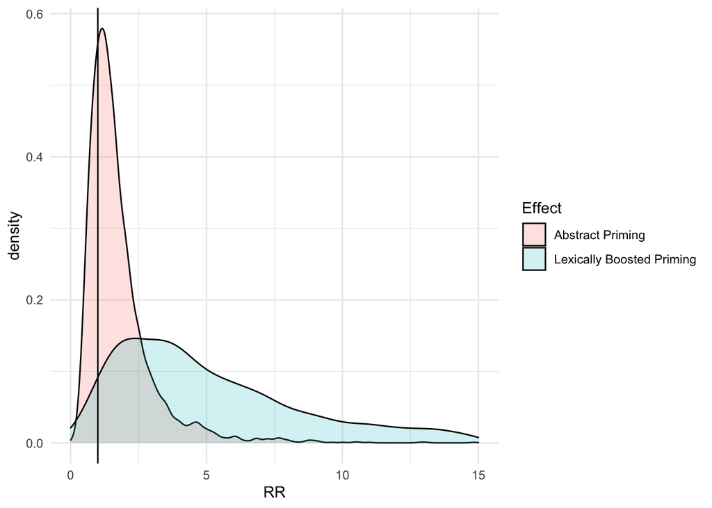

```r
RR1 <- ggplot(ps_means1, aes(x=value, fill=Effect)) + geom_density(alpha = .2) + xlim(0, 15) + geom_vline(xintercept=1) + theme_minimal() + xlab("RR")

RR1
```

## 4.2 DOD-Producers Only

Now we’ll consider only the kids who produced at least one DOD. The following output is really similar to that from the previous model, so I won’t add as much annotation.

```r
m2 <- brm(RESPONSE.CODE ~ 1 + Prime.Type*Overlap  +  (1 +  Prime.Type*Overlap | Blind_ID) + (1 +  Prime.Type*Overlap   | Target.verb), logit_prior,family="bernoulli", cores=4, data=DOD_42mo2, file="42mo/output/m2.rds")
m2<- add_criterion(m2, "loo")
```

```r
hypothesis(m2, "Prime.Type > 0")
```

```
## Hypothesis Tests for class b:
##         Hypothesis Estimate Est.Error CI.Lower CI.Upper Evid.Ratio Post.Prob
## 1 (Prime.Type) > 0     0.51      0.58    -0.39     1.44       5.07      0.84
##   Star
## 1
## ---
## 'CI': 90%-CI for one-sided and 95%-CI for two-sided hypotheses.
## '*': For one-sided hypotheses, the posterior probability exceeds 95%;
## for two-sided hypotheses, the value tested against lies outside the 95%-CI.
## Posterior probabilities of point hypotheses assume equal prior probabilities.
```

```r
hypothesis(m2, "Prime.Type:OverlapOverlap > 0")
```

```
## Hypothesis Tests for class b:
##                 Hypothesis Estimate Est.Error CI.Lower CI.Upper Evid.Ratio
## 1 (Prime.Type:Overl... > 0     1.74      0.94     0.31     3.33      39.82
##   Post.Prob Star
## 1      0.98    *
## ---
## 'CI': 90%-CI for one-sided and 95%-CI for two-sided hypotheses.
## '*': For one-sided hypotheses, the posterior probability exceeds 95%;
## for two-sided hypotheses, the value tested against lies outside the 95%-CI.
## Posterior probabilities of point hypotheses assume equal prior probabilities.
```

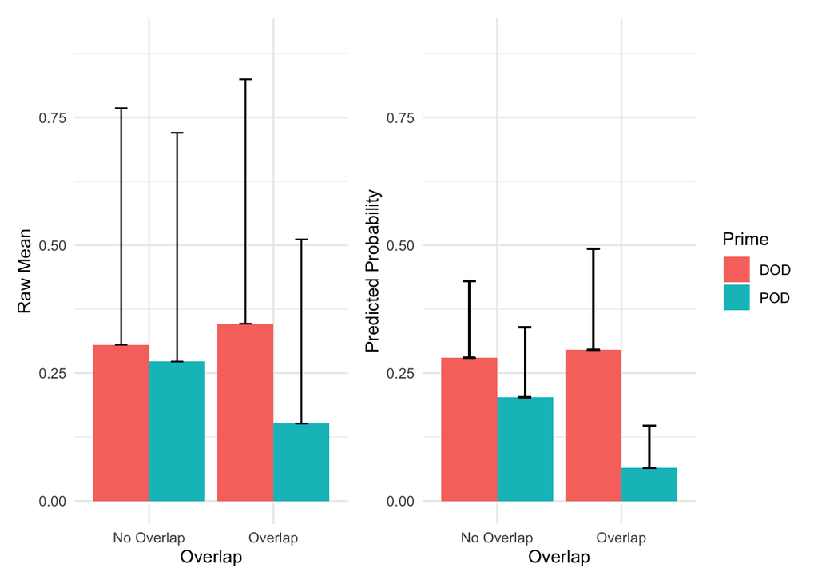

```r
p2 <- fitted(m2, re_formula=NA, scale="response") %>%
  cbind(DOD_42mo2) %>%
  dplyr::select(Prime, Overlap, Estimate, Est.Error) %>%
  ggplot(aes(y=Estimate, x=Overlap, fill=Prime )) +
  geom_bar(stat="identity",position="dodge") +
  geom_errorbar(aes(ymin=Estimate, ymax=Estimate+Est.Error), width=.2,
                 position=position_dodge(.9)) +
  theme_minimal() +
  ylim(0, .9) +
  labs(y="Predicted Probability") +
  theme(legend.position = "none")


p1b | p2 + plot_layout(guides = "collect") & theme(legend.position = "right")
```

```r
ps_means2 <- posterior_samples(m2) %>%
  dplyr::select(Intc = "b_Intercept", Prime = "b_Prime.Type", Overlap= "b_OverlapOverlap", Int = "b_Prime.Type:OverlapOverlap") %>%
  mutate(
    DOD_no = inv_logit_scaled(Intc + .5*Prime),
    POD_no = inv_logit_scaled(Intc  - .5*Prime),
    RR_ap = DOD_no/POD_no,
    DOD_o = inv_logit_scaled(Intc + .5*Prime + Overlap + .5*Int),
    POD_o = inv_logit_scaled(Intc - .5*Prime + Overlap - .5*Int),
    RR_ov = (DOD_o/POD_o)
  ) %>%
  dplyr::select(RR_ap, RR_ov) %>%
  pivot_longer(everything(), names_to = "RR", values_to = "value") %>%
  mutate(
    Effect = ifelse(RR=="RR_ap", yes= "Abstract Priming", no="Lexically Boosted Priming")
  )
ps_means2 %>%
  group_by(Effect) %>%
  dplyr::select(-"RR") %>%
  median_qi(.width=.9)
```

```
## # A tibble: 2 × 7
##   Effect                    value .lower .upper .width .point .interval
##   <chr>                     <dbl>  <dbl>  <dbl>  <dbl> <chr>  <chr>
## 1 Abstract Priming           1.43  0.747   3.24    0.9 median qi
## 2 Lexically Boosted Priming  6.27  1.79   32.8     0.9 median qi
```

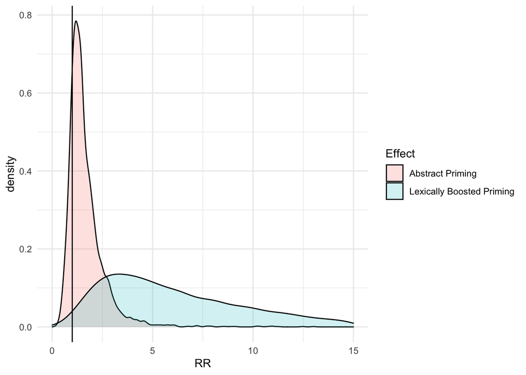

```r
RR2 <- ggplot(ps_means2, aes(x=value, fill=Effect)) + geom_density(alpha = .2) + xlim(0, 15) + geom_vline(xintercept=1) + theme_minimal() + xlab("RR")

RR2
```

```r
tab_model(m1, m2, show.re.var=FALSE, show.r2=FALSE, show.icc=FALSE, transform=NULL, collapse.ci=TRUE, p.style="scientific", ci.hyphen = " : ", dv.labels=c("Model 1",  "Model 2"), string.stat="",
          pred.labels=c(
            "Intercept",
            "Prime (DOD)",
            "Overlap",
            "Prime * Overlap"
          ))
```

|  | Model 1 | Model 2 |
| --- | --- | --- |
| Predictors | Log-Odds | Log-Odds |
| Intercept | -2.84 (-4.58 : -1.08) | -1.34 (-2.91 : 0.35) |
| Prime (DOD) | 0.40 (-0.75 : 1.72) | 0.48 (-0.59 : 1.68) |
| Overlap | -0.94 (-2.80 : 0.59) | -0.84 (-2.69 : 0.74) |
| Prime * Overlap | 1.26 (-0.69 : 3.41) | 1.70 (0.02 : 3.80) |
| N | 84 <sub>Blind_ID</sub> | 46 <sub>Blind_ID</sub> |
|  | 6 <sub>Target.verb</sub> | 6 <sub>Target.verb</sub> |
| Observations | 835 | 474 |

# 5 Bias Mismatch

Next consider how the biasmatch variable. For this, we’ll only consider the trials without lexical overlap.

```r
DOD_42mo3 <- filter(DOD_42mo, Overlap=="No Overlap")
m3 <- brm(RESPONSE.CODE ~ 1 +Prime.Type*biasmatch +
            (1 + Prime.Type*biasmatch| Blind_ID) +
            (1 + Prime.Type*biasmatch| Target.verb),
          logit_prior,
          family="bernoulli",
          iter=4000,
          cores=4,
          file="42mo/output/m3.rds",
          data=DOD_42mo3)
m3 <- add_criterion(m3, "loo")
summary(m3)
```

```
##  Family: bernoulli
##   Links: mu = logit
## Formula: RESPONSE.CODE ~ 1 + Prime.Type * biasmatch + (1 + Prime.Type * biasmatch | Blind_ID) + (1 + Prime.Type * biasmatch | Target.verb)
##    Data: DOD_42mo3 (Number of observations: 385)
##   Draws: 4 chains, each with iter = 4000; warmup = 2000; thin = 1;
##          total post-warmup draws = 8000
##
## Group-Level Effects:
## ~Blind_ID (Number of levels: 84)
##                                                     Estimate Est.Error l-95% CI
## sd(Intercept)                                           1.59      0.41     0.82
## sd(Prime.Type)                                          0.85      0.60     0.04
## sd(biasmatchmismatch)                                   0.72      0.54     0.03
## sd(Prime.Type:biasmatchmismatch)                        0.85      0.66     0.03
## cor(Intercept,Prime.Type)                               0.09      0.43    -0.74
## cor(Intercept,biasmatchmismatch)                       -0.02      0.43    -0.78
## cor(Prime.Type,biasmatchmismatch)                      -0.10      0.45    -0.85
## cor(Intercept,Prime.Type:biasmatchmismatch)             0.01      0.44    -0.79
## cor(Prime.Type,Prime.Type:biasmatchmismatch)           -0.12      0.45    -0.87
## cor(biasmatchmismatch,Prime.Type:biasmatchmismatch)    -0.03      0.45    -0.83
##                                                     u-95% CI Rhat Bulk_ESS
## sd(Intercept)                                           2.46 1.00     2856
## sd(Prime.Type)                                          2.23 1.00     2345
## sd(biasmatchmismatch)                                   2.03 1.00     1807
## sd(Prime.Type:biasmatchmismatch)                        2.43 1.00     3339
## cor(Intercept,Prime.Type)                               0.83 1.00     5884
## cor(Intercept,biasmatchmismatch)                        0.79 1.00     6070
## cor(Prime.Type,biasmatchmismatch)                       0.76 1.00     3955
## cor(Intercept,Prime.Type:biasmatchmismatch)             0.82 1.00     8506
## cor(Prime.Type,Prime.Type:biasmatchmismatch)            0.77 1.00     6086
## cor(biasmatchmismatch,Prime.Type:biasmatchmismatch)     0.80 1.00     5534
##                                                     Tail_ESS
## sd(Intercept)                                           3705
## sd(Prime.Type)                                          2493
## sd(biasmatchmismatch)                                   2629
## sd(Prime.Type:biasmatchmismatch)                        3354
## cor(Intercept,Prime.Type)                               5090
## cor(Intercept,biasmatchmismatch)                        5442
## cor(Prime.Type,biasmatchmismatch)                       5689
## cor(Intercept,Prime.Type:biasmatchmismatch)             5381
```

[output cut: 38 more lines]

```
## Population-Level Effects:
##                              Estimate Est.Error l-95% CI u-95% CI Rhat Bulk_ESS
## Intercept                       -2.41      0.91    -4.26    -0.63 1.00     2310
## Prime.Type                       0.93      0.84    -0.67     2.63 1.00     4264
## biasmatchmismatch               -0.65      0.63    -1.96     0.55 1.00     5086
## Prime.Type:biasmatchmismatch    -0.57      1.22    -2.91     1.99 1.00     4523
##                              Tail_ESS
## Intercept                        3561
## Prime.Type                       4367
## biasmatchmismatch                4669
## Prime.Type:biasmatchmismatch     4788
##
## Draws were sampled using sampling(NUTS). For each parameter, Bulk_ESS
## and Tail_ESS are effective sample size measures, and Rhat is the potential
## scale reduction factor on split chains (at convergence, Rhat = 1).
```

```r
#plot(m3)
#pp_check(m3)
```

```r
hypothesis(m3, "Prime.Type > 0")
```

```
## Hypothesis Tests for class b:
##         Hypothesis Estimate Est.Error CI.Lower CI.Upper Evid.Ratio Post.Prob
## 1 (Prime.Type) > 0     0.93      0.84    -0.37     2.33       7.39      0.88
##   Star
## 1
## ---
## 'CI': 90%-CI for one-sided and 95%-CI for two-sided hypotheses.
## '*': For one-sided hypotheses, the posterior probability exceeds 95%;
## for two-sided hypotheses, the value tested against lies outside the 95%-CI.
## Posterior probabilities of point hypotheses assume equal prior probabilities.
```

```r
hypothesis(m3, "Prime.Type:biasmatchmismatch > 0") # Bias mismatch
```

```
## Hypothesis Tests for class b:
##                 Hypothesis Estimate Est.Error CI.Lower CI.Upper Evid.Ratio
## 1 (Prime.Type:biasm... > 0    -0.57      1.22    -2.51     1.47       0.44
##   Post.Prob Star
## 1      0.31
## ---
## 'CI': 90%-CI for one-sided and 95%-CI for two-sided hypotheses.
## '*': For one-sided hypotheses, the posterior probability exceeds 95%;
## for two-sided hypotheses, the value tested against lies outside the 95%-CI.
## Posterior probabilities of point hypotheses assume equal prior probabilities.
```

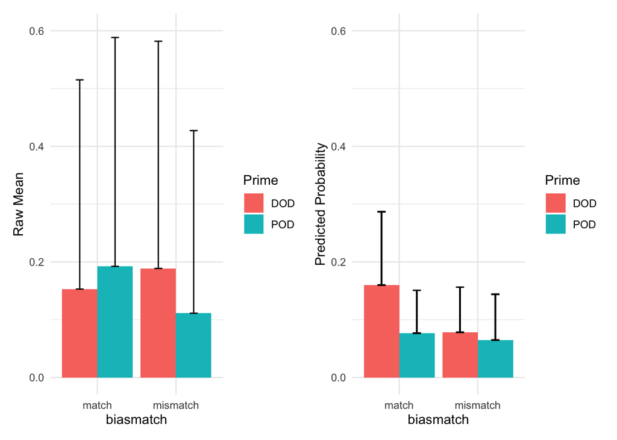

```r
p3 <- fitted(m3, re_formula=NA, scale="response") %>%
  cbind(DOD_42mo3) %>%
  dplyr::select(Prime, biasmatch, Estimate, Est.Error) %>%
  ggplot(aes(y=Estimate, x=biasmatch, fill=Prime )) +
  geom_bar(stat="identity",position="dodge") +
  geom_errorbar(aes(ymin=Estimate, ymax=Estimate+Est.Error), width=.2,
                 position=position_dodge(.9)) +
  theme_minimal() +
  ylim(0, .6) +
  labs(y="Predicted Probability") +
  theme(legend.position = "none")


p1c | p3 + plot_layout(guides = "collect") & theme(legend.position = "right")
```

One thing stands out about that graph: we see the opposite pattern of results in the raw data and in the model-implied values. Recall that when we plotted the effect of prime surprisal by verb, we saw mostly the opposite effect by verb as what we saw in the full sample. This means the discrpenacy above could reflect Simpson’s Paradox: an effect on the conditional distribution disappearing in the marginal distribution.

If the issue is Simpson’s Paradox, and not some sort of coding mistake, when we get rid of random effects by verb, the coefficients should change direction. I’ve fit the model without random effects by target word, and indeed the coefficient for the prime surprisal effect becomes positive. I’ve excluded it here for space reasons, but it’s in the R Markdown file.

```r
m3e <- brm(RESPONSE.CODE ~ 1 +Prime.Type*biasmatch + (1 + Prime.Type*biasmatch| Blind_ID), logit_prior, family="bernoulli", iter=4000, cores=4, file="42mo/output/m3e.rds", data=DOD_42mo3)
summary(m3e)
```

```
##  Family: bernoulli
##   Links: mu = logit
## Formula: RESPONSE.CODE ~ 1 + Prime.Type * biasmatch + (1 + Prime.Type * biasmatch | Blind_ID)
##    Data: DOD_42mo3 (Number of observations: 385)
##   Draws: 4 chains, each with iter = 4000; warmup = 2000; thin = 1;
##          total post-warmup draws = 8000
##
## Group-Level Effects:
## ~Blind_ID (Number of levels: 84)
##                                                     Estimate Est.Error l-95% CI
## sd(Intercept)                                           1.14      0.36     0.44
## sd(Prime.Type)                                          0.63      0.46     0.03
## sd(biasmatchmismatch)                                   0.57      0.43     0.03
## sd(Prime.Type:biasmatchmismatch)                        0.75      0.57     0.03
## cor(Intercept,Prime.Type)                               0.08      0.44    -0.76
## cor(Intercept,biasmatchmismatch)                       -0.01      0.44    -0.80
## cor(Prime.Type,biasmatchmismatch)                      -0.07      0.44    -0.84
## cor(Intercept,Prime.Type:biasmatchmismatch)            -0.04      0.44    -0.82
## cor(Prime.Type,Prime.Type:biasmatchmismatch)           -0.10      0.45    -0.86
## cor(biasmatchmismatch,Prime.Type:biasmatchmismatch)    -0.08      0.45    -0.85
##                                                     u-95% CI Rhat Bulk_ESS
## sd(Intercept)                                           1.88 1.00     2004
## sd(Prime.Type)                                          1.70 1.00     3710
## sd(biasmatchmismatch)                                   1.59 1.00     2278
## sd(Prime.Type:biasmatchmismatch)                        2.15 1.00     4147
## cor(Intercept,Prime.Type)                               0.85 1.00     9653
## cor(Intercept,biasmatchmismatch)                        0.80 1.00     8321
## cor(Prime.Type,biasmatchmismatch)                       0.77 1.00     5115
## cor(Intercept,Prime.Type:biasmatchmismatch)             0.79 1.00    10085
## cor(Prime.Type,Prime.Type:biasmatchmismatch)            0.78 1.00     8207
## cor(biasmatchmismatch,Prime.Type:biasmatchmismatch)     0.78 1.00     7123
##                                                     Tail_ESS
## sd(Intercept)                                           1523
## sd(Prime.Type)                                          4396
## sd(biasmatchmismatch)                                   3122
## sd(Prime.Type:biasmatchmismatch)                        5383
## cor(Intercept,Prime.Type)                               5822
## cor(Intercept,biasmatchmismatch)                        5352
## cor(Prime.Type,biasmatchmismatch)                       6454
## cor(Intercept,Prime.Type:biasmatchmismatch)             6376
## cor(Prime.Type,Prime.Type:biasmatchmismatch)            6059
## cor(biasmatchmismatch,Prime.Type:biasmatchmismatch)     6300
##
## Population-Level Effects:
##                              Estimate Est.Error l-95% CI u-95% CI Rhat Bulk_ESS
## Intercept                       -1.97      0.32    -2.67    -1.41 1.00     5502
## Prime.Type                      -0.37      0.49    -1.39     0.55 1.00     8521
## biasmatchmismatch               -0.45      0.43    -1.34     0.33 1.00     6788
## Prime.Type:biasmatchmismatch     1.23      0.76    -0.20     2.82 1.00     7478
##                              Tail_ESS
## Intercept                        4760
## Prime.Type                       5411
## biasmatchmismatch                4539
## Prime.Type:biasmatchmismatch     5439
##
## Draws were sampled using sampling(NUTS). For each parameter, Bulk_ESS
## and Tail_ESS are effective sample size measures, and Rhat is the potential
## scale reduction factor on split chains (at convergence, Rhat = 1).
```

## 5.1 DOD-Producers Only

```r
DOD_42mo4 <-
  DOD_42mo3 %>%
  filter(Prod_DOD > 0)
```

```r
m4 <- brm(RESPONSE.CODE ~ 1 +Prime.Type*biasmatch + (1 + Prime.Type*biasmatch| Blind_ID) + (1 + Prime.Type*biasmatch| Target.verb), logit_prior, family="bernoulli", iter=4000, cores=4, file="42mo/output/m4.rds", data=DOD_42mo4)
summary(m4)
```

```
##  Family: bernoulli
##   Links: mu = logit
## Formula: RESPONSE.CODE ~ 1 + Prime.Type * biasmatch + (1 + Prime.Type * biasmatch | Blind_ID) + (1 + Prime.Type * biasmatch | Target.verb)
##    Data: DOD_42mo4 (Number of observations: 218)
##   Draws: 4 chains, each with iter = 4000; warmup = 2000; thin = 1;
##          total post-warmup draws = 8000
##
## Group-Level Effects:
## ~Blind_ID (Number of levels: 46)
##                                                     Estimate Est.Error l-95% CI
## sd(Intercept)                                           0.49      0.33     0.03
## sd(Prime.Type)                                          0.91      0.63     0.04
## sd(biasmatchmismatch)                                   0.70      0.50     0.04
## sd(Prime.Type:biasmatchmismatch)                        0.88      0.68     0.03
## cor(Intercept,Prime.Type)                               0.03      0.44    -0.79
## cor(Intercept,biasmatchmismatch)                       -0.07      0.45    -0.84
## cor(Prime.Type,biasmatchmismatch)                      -0.10      0.44    -0.84
## cor(Intercept,Prime.Type:biasmatchmismatch)            -0.02      0.44    -0.81
## cor(Prime.Type,Prime.Type:biasmatchmismatch)           -0.13      0.46    -0.88
## cor(biasmatchmismatch,Prime.Type:biasmatchmismatch)    -0.03      0.45    -0.83
##                                                     u-95% CI Rhat Bulk_ESS
## sd(Intercept)                                           1.24 1.00     2417
## sd(Prime.Type)                                          2.34 1.00     2633
## sd(biasmatchmismatch)                                   1.86 1.00     2288
## sd(Prime.Type:biasmatchmismatch)                        2.54 1.00     3115
## cor(Intercept,Prime.Type)                               0.82 1.00     4682
## cor(Intercept,biasmatchmismatch)                        0.77 1.00     4081
## cor(Prime.Type,biasmatchmismatch)                       0.77 1.00     4037
## cor(Intercept,Prime.Type:biasmatchmismatch)             0.79 1.00     8073
## cor(Prime.Type,Prime.Type:biasmatchmismatch)            0.77 1.00     6624
## cor(biasmatchmismatch,Prime.Type:biasmatchmismatch)     0.80 1.00     6314
##                                                     Tail_ESS
## sd(Intercept)                                           2953
## sd(Prime.Type)                                          3399
## sd(biasmatchmismatch)                                   3428
## sd(Prime.Type:biasmatchmismatch)                        2915
## cor(Intercept,Prime.Type)                               4652
## cor(Intercept,biasmatchmismatch)                        4798
## cor(Prime.Type,biasmatchmismatch)                       5305
## cor(Intercept,Prime.Type:biasmatchmismatch)             5369
```

[output cut: 38 more lines]

```
## Population-Level Effects:
##                              Estimate Est.Error l-95% CI u-95% CI Rhat Bulk_ESS
## Intercept                       -1.01      0.84    -2.67     0.72 1.00     2289
## Prime.Type                       1.18      0.79    -0.31     2.79 1.00     4682
## biasmatchmismatch               -0.68      0.59    -1.92     0.44 1.00     4641
## Prime.Type:biasmatchmismatch    -0.83      1.16    -3.19     1.47 1.00     4722
##                              Tail_ESS
## Intercept                        4030
## Prime.Type                       4587
## biasmatchmismatch                4315
## Prime.Type:biasmatchmismatch     4935
##
## Draws were sampled using sampling(NUTS). For each parameter, Bulk_ESS
## and Tail_ESS are effective sample size measures, and Rhat is the potential
## scale reduction factor on split chains (at convergence, Rhat = 1).
```

```r
m4 <- add_criterion(m4, "loo")
```

```r
hypothesis(m4, "Prime.Type > 0")
```

```
## Hypothesis Tests for class b:
##         Hypothesis Estimate Est.Error CI.Lower CI.Upper Evid.Ratio Post.Prob
## 1 (Prime.Type) > 0     1.18      0.79    -0.06     2.46      16.13      0.94
##   Star
## 1
## ---
## 'CI': 90%-CI for one-sided and 95%-CI for two-sided hypotheses.
## '*': For one-sided hypotheses, the posterior probability exceeds 95%;
## for two-sided hypotheses, the value tested against lies outside the 95%-CI.
## Posterior probabilities of point hypotheses assume equal prior probabilities.
```

```r
hypothesis(m4, "Prime.Type:biasmatchmismatch > 0") # Bias mismatch
```

```
## Hypothesis Tests for class b:
##                 Hypothesis Estimate Est.Error CI.Lower CI.Upper Evid.Ratio
## 1 (Prime.Type:biasm... > 0    -0.83      1.16     -2.7     1.09       0.29
##   Post.Prob Star
## 1      0.23
## ---
## 'CI': 90%-CI for one-sided and 95%-CI for two-sided hypotheses.
## '*': For one-sided hypotheses, the posterior probability exceeds 95%;
## for two-sided hypotheses, the value tested against lies outside the 95%-CI.
## Posterior probabilities of point hypotheses assume equal prior probabilities.
```

```r
tab_model(m1, m2, m3, m4, show.re.var=FALSE, show.r2=FALSE, show.icc=FALSE, transform=NULL, collapse.ci=TRUE, p.style="scientific", ci.hyphen = " : ", dv.labels=c("Model 1",  "Model 2", "Model 3", "Model 4"), string.stat="", file="Table4",
           pred.labels=c(
            "Intercept",
            "Prime (DOD)",
            "Overlap",
            "Prime * Overlap",
            "Bias Mismatch (POD)",
            "Prime * Bias Mismatch "
          ))
```

|  | Model 1 | Model 2 | Model 3 | Model 4 |
| --- | --- | --- | --- | --- |
| Predictors | Log-Odds | Log-Odds | Log-Odds | Log-Odds |
| Intercept | -2.84 (-4.58 : -1.08) | -1.34 (-2.91 : 0.35) | -2.40 (-4.26 : -0.63) | -1.03 (-2.67 : 0.72) |
| Prime (DOD) | 0.40 (-0.75 : 1.72) | 0.48 (-0.59 : 1.68) | 0.92 (-0.67 : 2.63) | 1.16 (-0.31 : 2.79) |
| Overlap | -0.94 (-2.80 : 0.59) | -0.84 (-2.69 : 0.74) |  |  |
| Prime * Overlap | 1.26 (-0.69 : 3.41) | 1.70 (0.02 : 3.80) |  |  |
| Bias Mismatch (POD) |  |  | -0.62 (-1.96 : 0.55) | -0.67 (-1.92 : 0.44) |
| Prime * Bias Mismatch |  |  | -0.61 (-2.91 : 1.99) | -0.84 (-3.19 : 1.47) |
| N | 84 <sub>Blind_ID</sub> | 46 <sub>Blind_ID</sub> | 84 <sub>Blind_ID</sub> | 46 <sub>Blind_ID</sub> |
|  | 6 <sub>Target.verb</sub> | 6 <sub>Target.verb</sub> | 6 <sub>Target.verb</sub> | 6 <sub>Target.verb</sub> |
| Observations | 835 | 474 | 385 | 218 |